# Homework 04

Qi Yang

```r
library(tidyverse)
library(tidyr)
library(gapminder)
library(DT)
guest <- read_csv("https://raw.githubusercontent.com/STAT545-UBC/Classroom/master/data/wedding/attend.csv")
email <- read_csv("https://raw.githubusercontent.com/STAT545-UBC/Classroom/master/data/wedding/emails.csv")
```

## Exercise 1: Univariate Data Reshaping - Option 1

### 1. Produce a tibble with one row per year, and columns for life expectancy for two or more countries.

```r
lifeExp_comp <- gapminder %>%
  select(year, country, lifeExp) %>%  # Not necessary, saved simply for comparison with data re-lengthening
  filter(country == "Central African Republic" | country == "Japan")
lifeExp_comp_wider <- lifeExp_comp %>%
                      pivot_wider(id_col = year,
                      names_from = country,
                      values_from = lifeExp) %>%
                      rename(lifeExp_CAR = "Central African Republic", lifeExp_Japan = "Japan") %>%
                      # Rename to make the tibble nicer
                      round(digits = 2) # Round digits to 2
DT::datatable(lifeExp_comp_wider, rownames = FALSE)
```

| year | lifeExp_CAR | lifeExp_Japan |
| --- | --- | --- |
| 1952 | 35.46 | 63.03 |
| 1957 | 37.46 | 65.5 |
| 1962 | 39.48 | 68.73 |
| 1967 | 41.48 | 71.43 |
| 1972 | 43.46 | 73.42 |
| 1977 | 46.77 | 75.38 |
| 1982 | 48.3 | 77.11 |
| 1987 | 50.48 | 78.67 |
| 1992 | 49.4 | 79.36 |
| 1997 | 46.07 | 80.69 |

[output cut: 2 more lines]

### 2. Use the new data shape to scatterplot life expectancy for one country against that of another.

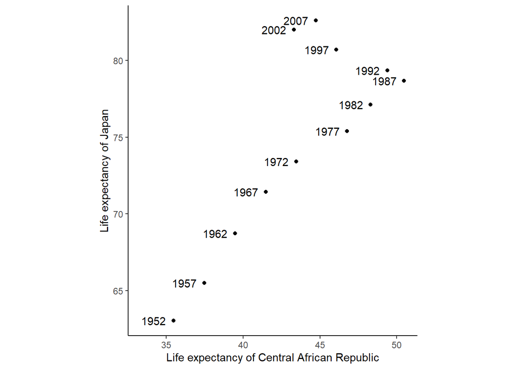

```r
lifeExp_comp_wider %>%
  ggplot(aes(lifeExp_CAR, lifeExp_Japan, label = year)) + # Add year labels
  geom_point()+
  labs(x = "Life expectancy of Central African Republic",
       y = "Life expectancy of Japan")+
  geom_text(hjust = 0, nudge_x = -2.1) + # Put year labels at proper places
  theme_classic() +
  coord_fixed() # Make axes on the same scale
```

The scatterplot shows the life expectancy of **Japan** vs. **CAR**. We can see huge differences between their life expectancies more clearly and directly.

### 3. Re-lengthen the data.

```r
lifeExp_comp_wider %>%
   rename("Central African Republic" = "lifeExp_CAR", "Japan" = "lifeExp_Japan") %>%
   # Give back their original names
   pivot_longer(cols = c(-year),
               names_to = "country",
               values_to = "lifeExp") %>% # Re-lengthening
   arrange(country) %>% # Arrange rows in the same order as before
   DT::datatable()
```

|  | year | country | lifeExp |
| --- | --- | --- | --- |
| 1 | 1952 | Central African Republic | 35.46 |
| 2 | 1957 | Central African Republic | 37.46 |
| 3 | 1962 | Central African Republic | 39.48 |
| 4 | 1967 | Central African Republic | 41.48 |
| 5 | 1972 | Central African Republic | 43.46 |
| 6 | 1977 | Central African Republic | 46.77 |
| 7 | 1982 | Central African Republic | 48.3 |
| 8 | 1987 | Central African Republic | 50.48 |
| 9 | 1992 | Central African Republic | 49.4 |
| 10 | 1997 | Central African Republic | 46.07 |

[output cut: 14 more lines]

## Exercise 2: Multivariate Data Reshaping - Option 1

### 1. Make a tibble with one row per year, and columns for life expectancy and GDP per capita for two countries.

```r
lifeGDP <- gapminder %>%
           select(year, country, lifeExp, gdpPercap) %>%
           filter(country == "Central African Republic" | country == "Japan")
lifeGDP_wider <- lifeGDP %>%
                 pivot_wider(id_cols     = c(year),
                 names_from  = c(country),
                 names_sep   = "_",
                 values_from = c(lifeExp, gdpPercap) ) %>%
                 round(digits = 2) %>%
                 rename(lifeExp_CAR = "lifeExp_Central African Republic", gdpPercap_CAR = "gdpPercap_Central African Republic")
DT::datatable(lifeGDP_wider)
```

|  | year | lifeExp_CAR | lifeExp_Japan | gdpPercap_CAR | gdpPercap_Japan |
| --- | --- | --- | --- | --- | --- |
| 1 | 1952 | 35.46 | 63.03 | 1071.31 | 3216.96 |
| 2 | 1957 | 37.46 | 65.5 | 1190.84 | 4317.69 |
| 3 | 1962 | 39.48 | 68.73 | 1193.07 | 6576.65 |
| 4 | 1967 | 41.48 | 71.43 | 1136.06 | 9847.79 |
| 5 | 1972 | 43.46 | 73.42 | 1070.01 | 14778.79 |
| 6 | 1977 | 46.77 | 75.38 | 1109.37 | 16610.38 |
| 7 | 1982 | 48.3 | 77.11 | 956.75 | 19384.11 |
| 8 | 1987 | 50.48 | 78.67 | 844.88 | 22375.94 |
| 9 | 1992 | 49.4 | 79.36 | 747.91 | 26824.9 |
| 10 | 1997 | 46.07 | 80.69 | 740.51 | 28816.58 |

[output cut: 2 more lines]

This tibble shows the life expectancy and GDP per capita of **CAR** and **Japan** across years. We can see tremendous gaps between not only life expectancies but also GDP per capita: e.g. In 1997, Japan’s GDP per capita was almost *40* times higher than CAR!

### 2. Re-lengthen the data.

```r
lifeGDP_wider %>%
    rename("lifeExp_Central African Republic" = "lifeExp_CAR", "gdpPercap_Central African Republic" = "gdpPercap_CAR") %>%
    pivot_longer(cols      = c(-year),
               names_to  = c(".value", "country"),
               names_sep = "_") %>%
    arrange(country) %>% # Arrange rows in the same order as before
DT::datatable()
```

|  | year | country | lifeExp | gdpPercap |
| --- | --- | --- | --- | --- |
| 1 | 1952 | Central African Republic | 35.46 | 1071.31 |
| 2 | 1957 | Central African Republic | 37.46 | 1190.84 |
| 3 | 1962 | Central African Republic | 39.48 | 1193.07 |
| 4 | 1967 | Central African Republic | 41.48 | 1136.06 |
| 5 | 1972 | Central African Republic | 43.46 | 1070.01 |
| 6 | 1977 | Central African Republic | 46.77 | 1109.37 |
| 7 | 1982 | Central African Republic | 48.3 | 956.75 |
| 8 | 1987 | Central African Republic | 50.48 | 844.88 |
| 9 | 1992 | Central African Republic | 49.4 | 747.91 |
| 10 | 1997 | Central African Republic | 46.07 | 740.51 |

[output cut: 14 more lines]

## Exercise 3: Table Joins

### 3.1 Add a column for email address for each guest in the guestlist.

```r
email_separate <- email %>%
                  separate_rows(guest, sep = ", ") %>% # let emails separated for each person
                  rename(name = guest) # rename for table joining
guest %>%
   left_join(email_separate, by = c("name")) %>% # add email for each person in guest dataset
   DT::datatable(rownames = FALSE)
```

| party | name | meal_wedding | meal_brunch | attendance_wedding | attendance_brunch | attendance_golf | email |
| --- | --- | --- | --- | --- | --- | --- | --- |
| 1 | Sommer Medrano | PENDING | PENDING | PENDING | PENDING | PENDING | sommm@gmail.com |
| 1 | Phillip Medrano | vegetarian | Menu C | CONFIRMED | CONFIRMED | CONFIRMED | sommm@gmail.com |
| 1 | Blanka Medrano | chicken | Menu A | CONFIRMED | CONFIRMED | CONFIRMED | sommm@gmail.com |
| 1 | Emaan Medrano | PENDING | PENDING | PENDING | PENDING | PENDING | sommm@gmail.com |
| 2 | Blair Park | chicken | Menu C | CONFIRMED | CONFIRMED | CONFIRMED | bpark@gmail.com |
| 2 | Nigel Webb |  |  | CANCELLED | CANCELLED | CANCELLED | bpark@gmail.com |
| 3 | Sinead English | PENDING | PENDING | PENDING | PENDING | PENDING | singlish@hotmail.ca |
| 4 | Ayra Marks | vegetarian | Menu B | PENDING | PENDING | PENDING | marksa42@gmail.com |
| 5 | Atlanta Connolly | PENDING | PENDING | PENDING | PENDING | PENDING |  |
| 5 | Denzel Connolly | fish | Menu B | CONFIRMED | CONFIRMED | CONFIRMED |  |

[output cut: 20 more lines]

### 3.2 Show people we have emails for yet are not on the guestlist.

```r
email_separate %>%
  anti_join(guest, by = c("name")) %>%
  DT::datatable(rownames = FALSE)
```

| name | email |
| --- | --- |
| Turner Jones | tjjones12@hotmail.ca |
| Albert Marshall | themarshallfamily1234@gmail.com |
| Vivian Marshall | themarshallfamily1234@gmail.com |

### 3.3 Guestlist that includes everyone we have emails for.

```r
guest %>%
  full_join(email_separate, by = c("name")) %>%
  DT::datatable(rownames = FALSE)
```

| party | name | meal_wedding | meal_brunch | attendance_wedding | attendance_brunch | attendance_golf | email |
| --- | --- | --- | --- | --- | --- | --- | --- |
| 1 | Sommer Medrano | PENDING | PENDING | PENDING | PENDING | PENDING | sommm@gmail.com |
| 1 | Phillip Medrano | vegetarian | Menu C | CONFIRMED | CONFIRMED | CONFIRMED | sommm@gmail.com |
| 1 | Blanka Medrano | chicken | Menu A | CONFIRMED | CONFIRMED | CONFIRMED | sommm@gmail.com |
| 1 | Emaan Medrano | PENDING | PENDING | PENDING | PENDING | PENDING | sommm@gmail.com |
| 2 | Blair Park | chicken | Menu C | CONFIRMED | CONFIRMED | CONFIRMED | bpark@gmail.com |
| 2 | Nigel Webb |  |  | CANCELLED | CANCELLED | CANCELLED | bpark@gmail.com |
| 3 | Sinead English | PENDING | PENDING | PENDING | PENDING | PENDING | singlish@hotmail.ca |
| 4 | Ayra Marks | vegetarian | Menu B | PENDING | PENDING | PENDING | marksa42@gmail.com |
| 5 | Atlanta Connolly | PENDING | PENDING | PENDING | PENDING | PENDING |  |
| 5 | Denzel Connolly | fish | Menu B | CONFIRMED | CONFIRMED | CONFIRMED |  |

[output cut: 23 more lines]